# Project: No-show appointments - [KaggleV2-May-2016]

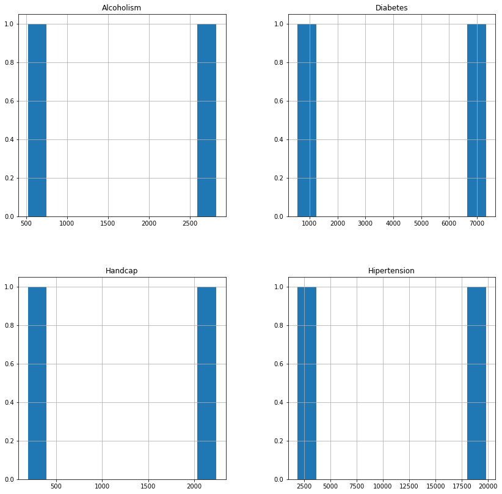

```python
df.groupby(['Scholarship'])['Hipertension','Alcoholism','Handcap','Diabetes'].sum().hist(figsize=(14,14));
```

Histgram of summation of people who have scholarship or not with any diesase like : ['Hipertension','Alcoholism','Handcap','Diabetes','Scholarship']

```python
df.groupby(['Scholarship'])['Hipertension','Alcoholism','Handcap','Diabetes'].count()
```

| Scholarship | Hipertension | Alcoholism | Handcap | Diabetes |
| --- | --- | --- | --- | --- |
| 0 | 99091 | 99091 | 99091 | 99091 |
| 1 | 10801 | 10801 | 10801 | 10801 |

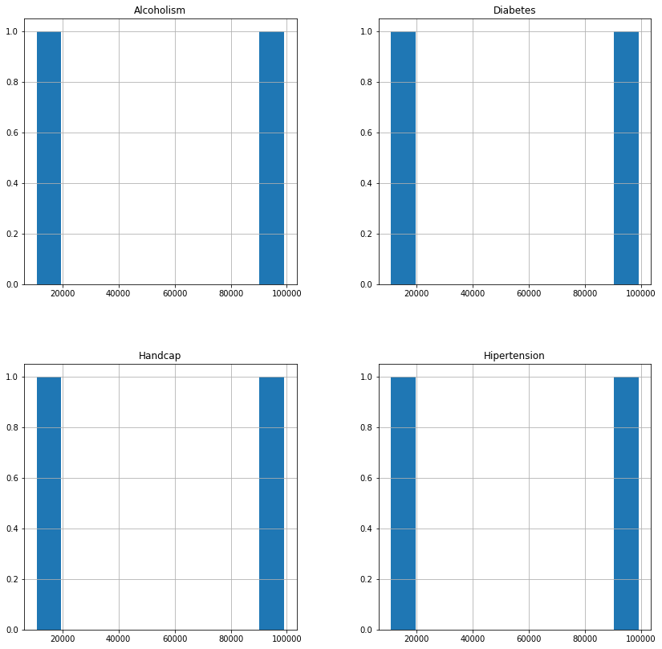

```python
df.groupby(['Scholarship'])['Hipertension','Alcoholism','Handcap','Diabetes'].count().hist(figsize=(14,14));
```

```python
df.groupby(['Diabetes'])['Hipertension'].mean()
```

```
Diabetes
0    0.149325
1    0.816546
Name: Hipertension, dtype: float64
```

average people who have Hipertension and Diabetes

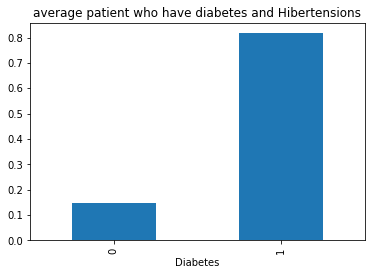

```python
df.groupby(['Diabetes'])['Hipertension'].mean().plot(kind = 'bar',title='average patient who have diabetes and Hibertensions');
```

Histgram of average people who have Hipertension and Diabetes

```python
df.groupby(['Alcoholism'])['Handcap'].mean()
```

```
Alcoholism
0    0.022046
1    0.024821
Name: Handcap, dtype: float64
```

average people who have Alcoholism and Handcap

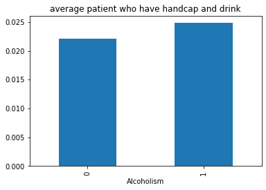

```python
df.groupby(['Alcoholism'])['Handcap'].mean().plot(kind = 'bar' , title ='average patient who have handcap and drink');
```

Histgram of average people who have Alcoholism and Handcap

```python
df.groupby(['SMS_received'])['Scholarship'].mean()
```

```
SMS_received
0    0.098051
1    0.098782
Name: Scholarship, dtype: float64
```

average people who have Scholarship and SMS_received

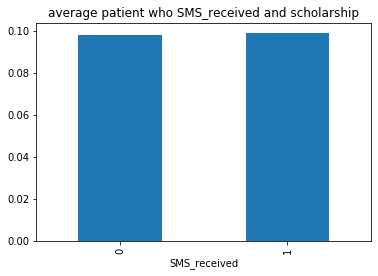

```python
df.groupby(['SMS_received'])['Scholarship'].mean().plot(kind = 'bar',title = 'average patient who SMS_received and scholarship');
```

Histgram of average people who have Scholarship and SMS_received

```python
df.Neighbourhood.value_counts()
```

```
JARDIM CAMBURI                 7616
MARIA ORTIZ                    5804
RESISTÊNCIA                    4387
JARDIM DA PENHA                3873
ITARARÉ                        3470
                               ...
ILHA DO BOI                      35
ILHA DO FRADE                    10
AEROPORTO                         8
ILHAS OCEÂNICAS DE TRINDADE       2
PARQUE INDUSTRIAL                 1
Name: Neighbourhood, Length: 81, dtype: int64
```

number of (value) neighbourhood hosbital that repeated in column

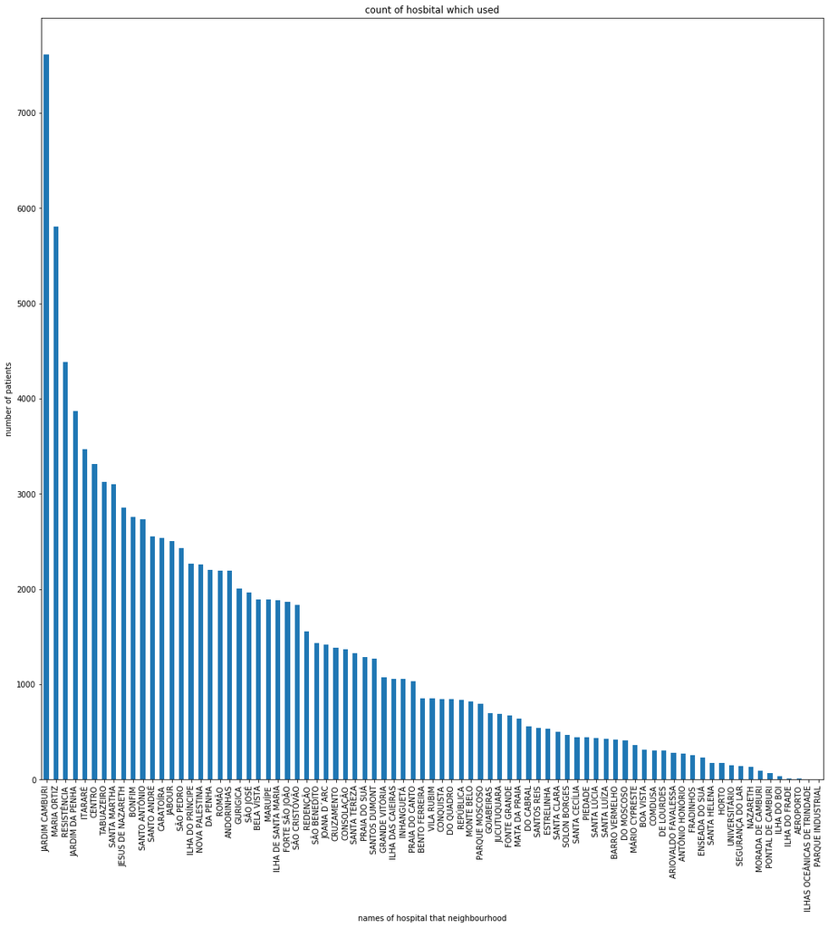

```python
df.Neighbourhood.value_counts().plot(kind='bar',figsize=(18,18));
plt.ylabel('number of patients')
plt.xlabel('names of hospital that neighbourhood')
plt.title('count of hosbital which used');
```

draw a bar diagram for number of (value) neighbourhood hosbital that repeated in column

```python
df.Neighbourhood.count()
```

```
109892
```

number of neighbourhood hosbital in dataset

```python
df.Neighbourhood.describe()
```

```
count             109892
unique                81
top       JARDIM CAMBURI
freq                7616
Name: Neighbourhood, dtype: object
```

descriptive statistical for neighbourhood column

```python
df.ScheduledDay.value_counts()
```

```
2016-05-06 07:09:54+00:00    23
2016-05-06 07:09:53+00:00    23
2016-04-25 17:17:46+00:00    22
2016-04-25 17:18:27+00:00    22
2016-04-25 17:17:23+00:00    19
                             ..
2016-04-06 09:43:40+00:00     1
2016-06-06 15:24:39+00:00     1
2016-05-11 13:55:03+00:00     1
2016-05-02 07:34:29+00:00     1
2016-05-19 16:59:13+00:00     1
Name: ScheduledDay, Length: 103549, dtype: int64
```

number of (value) scheduledday that repeated in column

```python
df.ScheduledDay.describe()
```

```
count                        109892
unique                       103549
top       2016-05-06 07:09:54+00:00
freq                             23
first     2015-11-10 07:13:56+00:00
last      2016-06-08 20:07:23+00:00
Name: ScheduledDay, dtype: object
```

descriptive statistical for ScheduledDay column

```python
df.AppointmentDay.describe()
```

```
count                        109892
unique                           27
top       2016-06-06 00:00:00+00:00
freq                           4683
first     2016-04-29 00:00:00+00:00
last      2016-06-08 00:00:00+00:00
Name: AppointmentDay, dtype: object
```

descriptive statistical for AppointmentDay column

```python
df.Noshow.value_counts()
```

```
No     87794
Yes    22098
Name: Noshow, dtype: int64
```

number of patients who will come or not

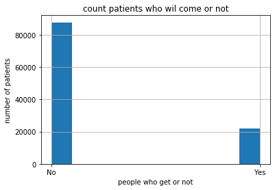

```python
df.Noshow.hist();
plt.ylabel('number of patients')
plt.xlabel('people who get or not')
plt.title('count patients who wil come or not');
```